# A05_naivebayes

Verena Haunschmid

25 March 2016

## Load library

The naive bayes algorithm is included in the library `e1071`. For visualisation I use `ggplot2`.

```r
library(e1071)
library(ggplot2)
```

## Data

The data was downloaded directly in R (most read methods in R do not only take file paths but also URLs). The second line sets a seed such that everytime the code is executed the test samples selected in the third line are the same. Approximately 10% of the samples are chosen as test samples.

```r
load("data.RData")
```

```r
mush_data<-read.csv("https://archive.ics.uci.edu/ml/machine-learning-databases/mushroom/agaricus-lepiota.data", sep=",", header=FALSE)
set.seed(5678)
mush_test<-sample(1:nrow(mush_data), nrow(mush_data)*0.1)
mush_data_melt <- melt(mush_data, id.vars = "edible")
```

To chose test samples also the following code can be used. It randomly generates `n` numbers between 0 and 1 and each sample with a value below 0.1 is assigned to the test set.

```r
which(runif(nrow(mush_data)) <= 0.1)
```

Sampling is important because the data might have been collected in a specified order.

Before applying any algorithm it’s suggested to look into the data. Use `summary` and `head` to get some info about the data set.

```r
summary(mush_data)
```

```
##  edible   cap-shape cap-surface   cap-color    bruises       odor
##  e:4208   b: 452    f:2320      n      :2284   f:4748   n      :3528
##  p:3916   c:   4    g:   4      g      :1840   t:3376   f      :2160
##           f:3152    s:2556      e      :1500            s      : 576
##           k: 828    y:3244      y      :1072            y      : 576
##           s:  32                w      :1040            a      : 400
##           x:3656                b      : 168            l      : 400
##                                 (Other): 220            (Other): 484
##  gill-attachment gill-spacing gill-size   gill-color   stalk-shape
##  a: 210          c:6812       b:5612    b      :1728   e:3516
##  f:7914          w:1312       n:2512    p      :1492   t:4608
##                                         w      :1202
##                                         n      :1048
##                                         g      : 752
##                                         h      : 732
##                                         (Other):1170
##  stalk-root stalk-surface-above-ring stalk-surface-below-ring
##  ?:2480     f: 552                   f: 600
##  b:3776     k:2372                   k:2304
##  c: 556     s:5176                   s:4936
##  e:1120     y:  24                   y: 284
##  r: 192
##
##
##  stalk-color-above-ring stalk-color-below-ring veil-type veil-color
##  w      :4464           w      :4384           p:8124    n:  96
##  p      :1872           p      :1872                     o:  96
##  g      : 576           g      : 576                     w:7924
##  n      : 448           n      : 512                     y:   8
##  b      : 432           b      : 432
##  o      : 192           o      : 192
##  (Other): 140           (Other): 156
##  ring-number ring-type spore-print-color population habitat
##  n:  36      e:2776    w      :2388      a: 384     d:3148
##  o:7488      f:  48    n      :1968      c: 340     g:2148
##  t: 600      l:1296    k      :1872      n: 400     l: 832
##              n:  36    h      :1632      s:1248     m: 292
##              p:3968    r      :  72      v:4040     p:1144
##                        b      :  48      y:1712     u: 368
##                        (Other): 144                 w: 192
```

```r
head(mush_data)
```

```
##   edible cap-shape cap-surface cap-color bruises odor gill-attachment
## 1      p         x           s         n       t    p               f
## 2      e         x           s         y       t    a               f
## 3      e         b           s         w       t    l               f
## 4      p         x           y         w       t    p               f
## 5      e         x           s         g       f    n               f
## 6      e         x           y         y       t    a               f
##   gill-spacing gill-size gill-color stalk-shape stalk-root
## 1            c         n          k           e          e
## 2            c         b          k           e          c
## 3            c         b          n           e          c
## 4            c         n          n           e          e
## 5            w         b          k           t          e
## 6            c         b          n           e          c
##   stalk-surface-above-ring stalk-surface-below-ring stalk-color-above-ring
```

[output cut: 20 more lines]

All values are categorical which is different from many datasets and makes it interesting for analysis. In the last section you can see plots for each feature.

## Naive bayes on all features

```r
training_features <- names(mush_data)[-1]
target <- "edible"

nb_mush <- naiveBayes(mush_data[-mush_test, training_features], mush_data[-mush_test, target])
pred_mush_test <- predict(nb_mush, mush_data[mush_test, training_features])
pred_mush_train <- predict(nb_mush, mush_data[-mush_test, training_features])
tab1 <- table(pred_mush_test, mush_data[mush_test, target])
tab2 <- table(pred_mush_train, mush_data[-mush_test, target])
```

### Confusion matrix test data

```r
kable(tab1, col.names = c("e - truth", "p - truth"))
```

|  | e - truth | p - truth |
| --- | --- | --- |
| e | 404 | 49 |
| p | 1 | 358 |

#### Accuracy

```r
(tab1[1,1]+tab1[2,2])/sum(tab1)
```

```
## [1] 0.9384236
```

### Confusion matrix training data

```r
kable(tab2, col.names = c("e - truth", "p - truth"))
```

|  | e - truth | p - truth |
| --- | --- | --- |
| e | 3777 | 404 |
| p | 26 | 3105 |

#### Accuracy

```r
(tab2[1,1]+tab2[2,2])/sum(tab2)
```

```
## [1] 0.9411926
```

## Naive bayes on selected features (see below)

```r
training_features <- c("bruises", "odor", "gill-spacing", "gill-size", "gill-color", "ring-type", "spore-print-color", "population")
nb_mush <- naiveBayes(mush_data[-mush_test, training_features], mush_data[-mush_test, target])
pred_mush_test <- predict(nb_mush, mush_data[mush_test, training_features])
pred_mush_train <- predict(nb_mush, mush_data[-mush_test, training_features])
tab1 <- table(pred_mush_test, mush_data[mush_test, target])
tab2 <- table(pred_mush_train, mush_data[-mush_test, target])
```

### Confusion matrix test data

```r
kable(table(pred_mush_test, mush_data[mush_test, target]), col.names = c("e - truth", "p - truth"))
```

[output not shown]

#### Accuracy

```r
(tab1[1,1]+tab1[2,2])/sum(tab1)
```

```
## [1] 0.9679803
```

### Confusion matrix training data

```r
kable(table(pred_mush_train, mush_data[-mush_test, target]), col.names = c("e - truth", "p - truth"))
```

|  | e - truth | p - truth |
| --- | --- | --- |
| e | 3776 | 197 |
| p | 27 | 3312 |

#### Accuracy

```r
(tab2[1,1]+tab2[2,2])/sum(tab2)
```

```
## [1] 0.9693654
```

## Naive bayes on feature odor

```r
training_features <- c("odor")
nb_mush <- naiveBayes(data.frame("odor" = mush_data[-mush_test, training_features]), mush_data[-mush_test, target])
pred_mush_test <- predict(nb_mush, data.frame("odor" = mush_data[mush_test, training_features]))
pred_mush_train <- predict(nb_mush, data.frame("odor" = mush_data[-mush_test, training_features]))
tab1 <- table(pred_mush_test, mush_data[mush_test, target])
tab2 <- table(pred_mush_train, mush_data[-mush_test, target])
```

### Confusion matrix test data

```r
kable(table(pred_mush_test, mush_data[mush_test, target]), col.names = c("e - truth", "p - truth"))
```

|  | e - truth | p - truth |
| --- | --- | --- |
| e | 405 | 11 |
| p | 0 | 396 |

#### Accuracy

```r
(tab1[1,1]+tab1[2,2])/sum(tab1)
```

```
## [1] 0.9864532
```

### Confusion matrix training data

```r
kable(table(pred_mush_train, mush_data[-mush_test, target]), col.names = c("e - truth", "p - truth"))
```

[output not shown]

```r
(tab2[1,1]+tab2[2,2])/sum(tab2)
```

```
## [1] 0.985093
```

## Visual feature selection

Since the dataset has many features I thought it would be useful to look at the features first and maybe it would be possible to preselect some features. So far I don’t know of any method like correlation for numerical values that can also compute a correlation value for categorical data so I just chose features manually that I thought would be useful. This sections shows the plots that I created.

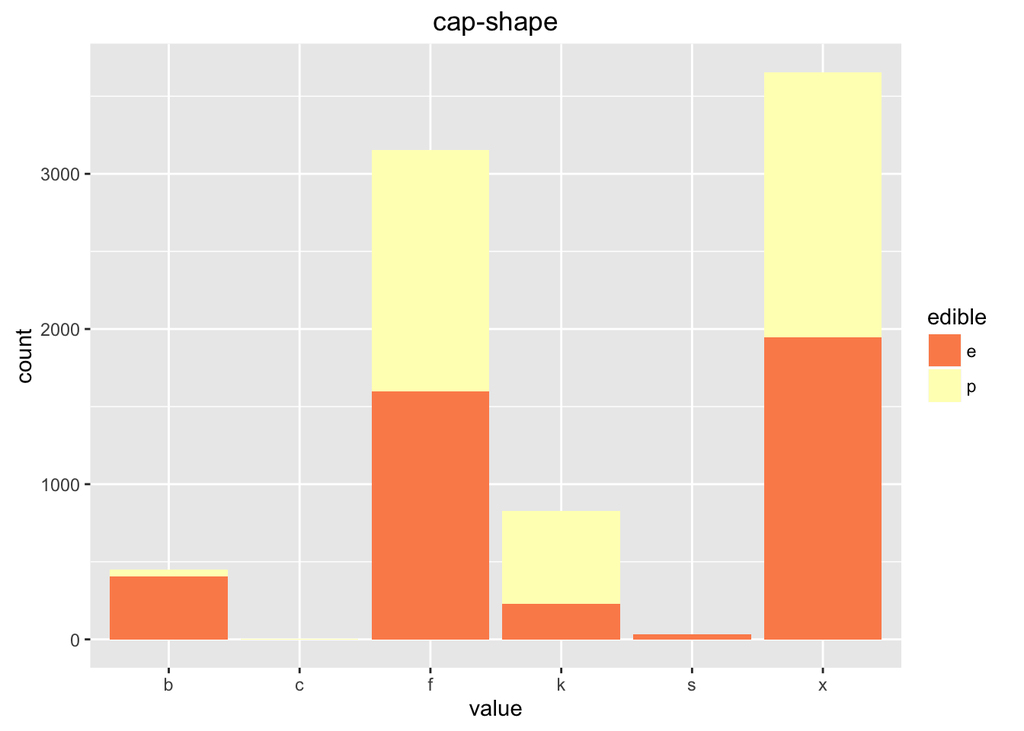

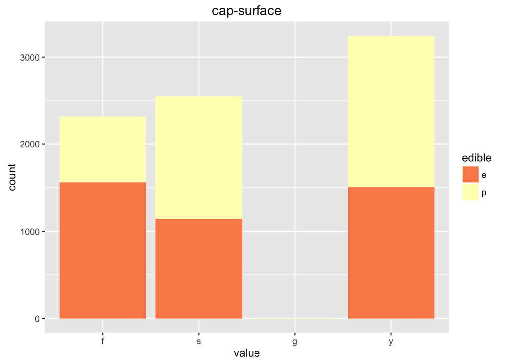

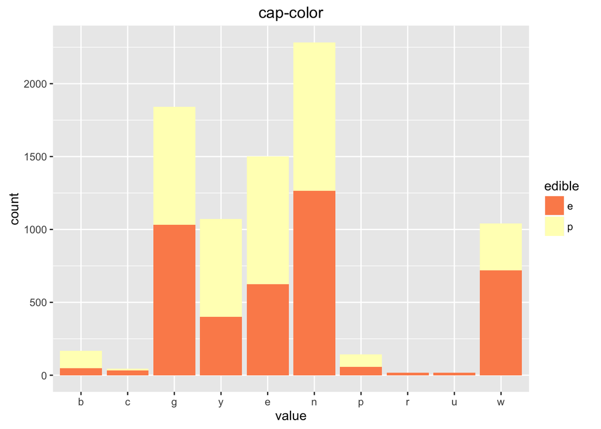

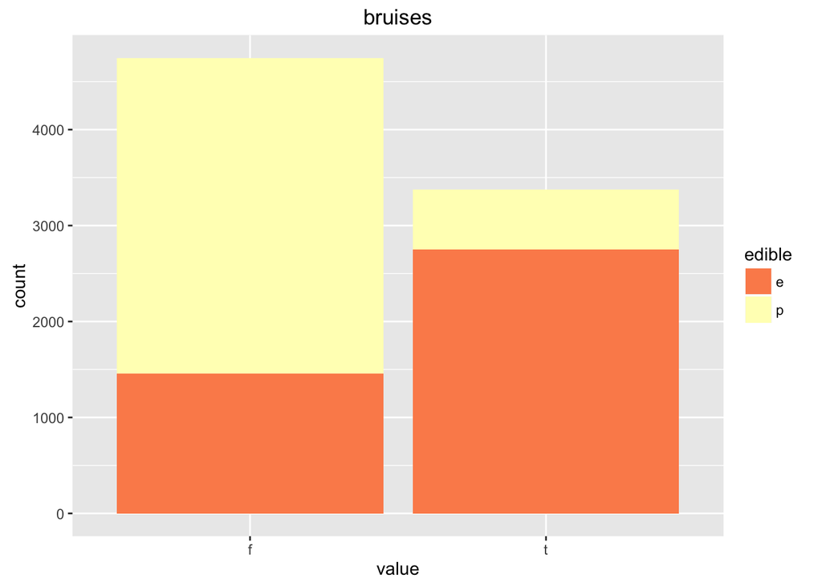

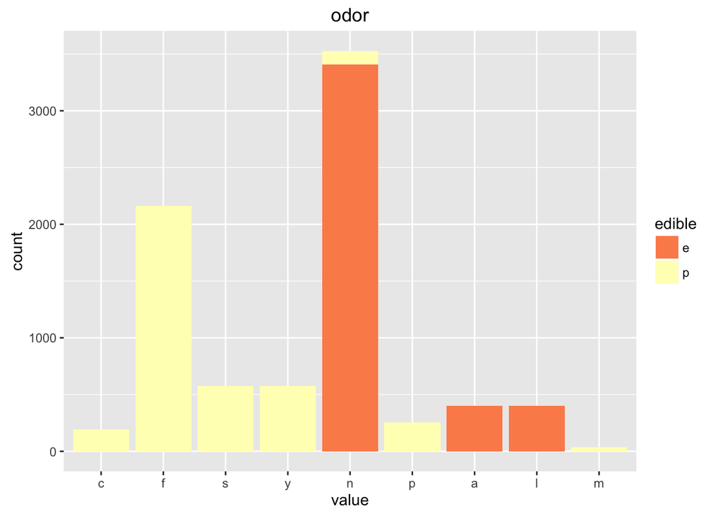

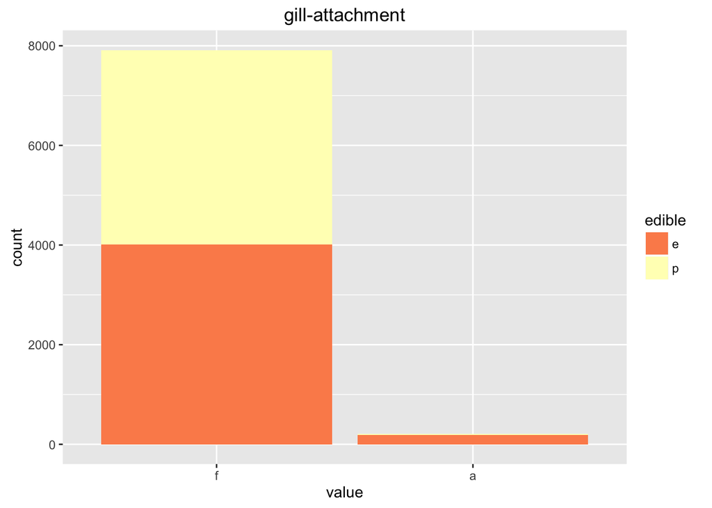

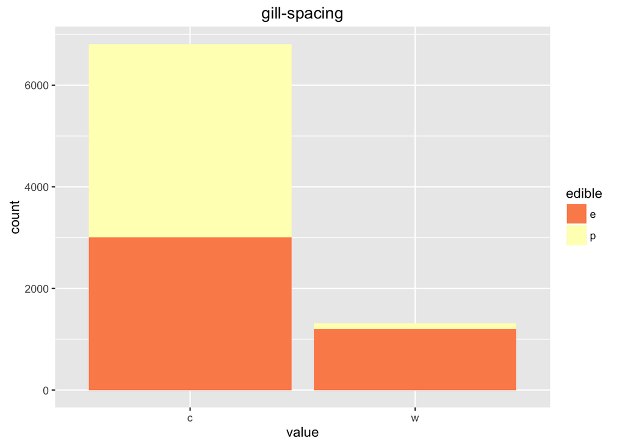

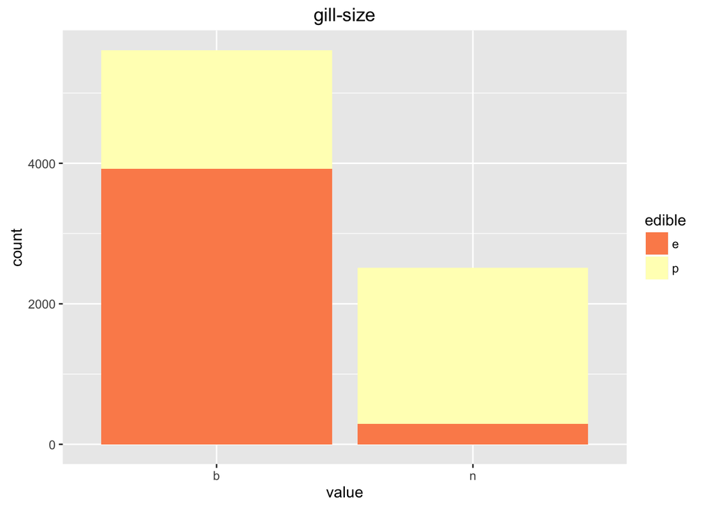

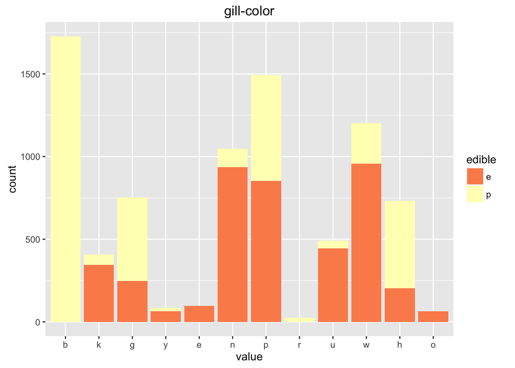

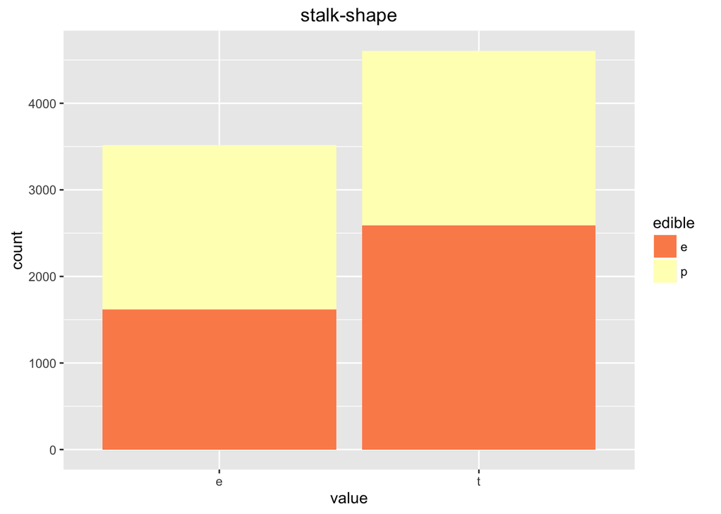

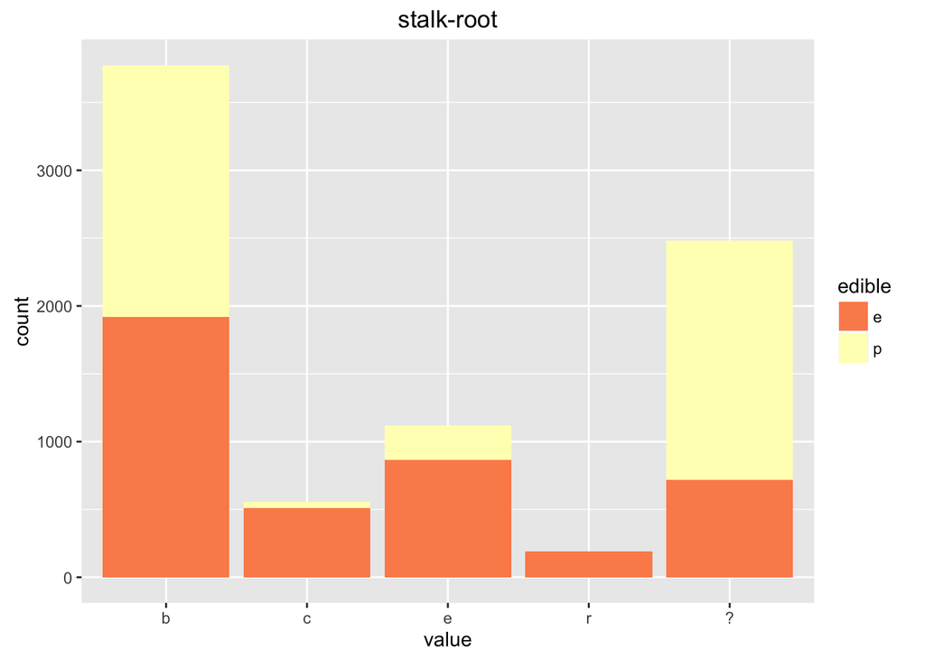

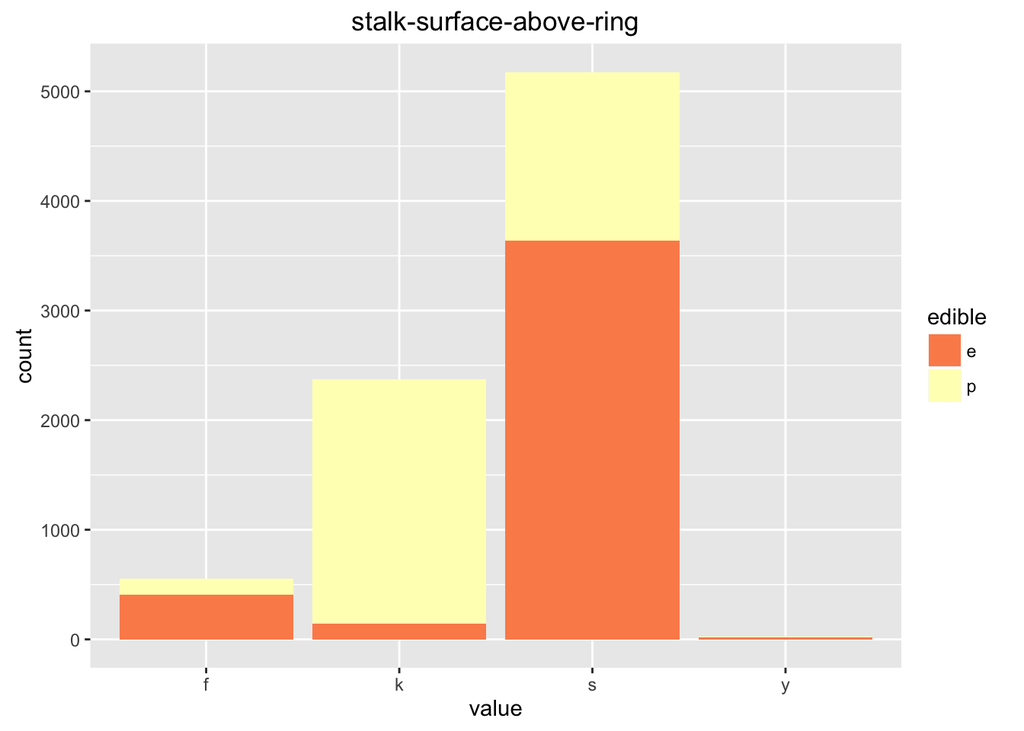

[10 more figures not shown]

## Conclusion

It’s interesting to see that reducing the number of features increases the accuracy. Using only one feature, **odor**, yields the highest accuracy. I conclude that analysing the data first before performing algorithms is an important step.

It can also be seen that test and training accuracy are very close for all 3 models, from which I conclude that the Naive Bayes algorithm does not overfit on the training data.

## Future work

There are still a few things that could/should be done. Not only accuracy, but also precision/recall should be computed and compared. Furthermore the split into training/test set should be performed several times to average over the model performance (Cross Validation).